# obesity report

Renata Mutesah (2797482), Jada van Heyningen (2801118), Matilde Maio (2861974), Eren Murtezaoglu (2819813)

24/06/2025`

# Title Page

Obesity

Group: Tutorial 4

Tutorial lecturer: Chantal

# Part 1 - Identify a Social Problem

Obesity is a growing social problem with significant public health, economic, and societal implications. With many factors impacting the rate of obesity. Some including poor diets, mental health issues, low income, and lack of education. In the united states of America, more than 100 millions adults (CDC, 2024) have obesity, causing the USA to rank in the top 10 (Ranking (% obesity by country), n.d.) countries with the highest obesity percentage. It contributes to rising rates of chronic diseases like diabetes, heart disease, and certain cancers, placing immense pressure on healthcare systems. In many communities, limited access to healthy food and safe recreational spaces further deepens health inequalities.  
Exploring the correlation between education, income, and obesity is highly relevant because both factors significantly influence health behaviors and access to resources. Individuals with lower levels of education may have limited knowledge about nutrition and the long-term consequences of poor dietary habits. Similarly, those with lower income often face barriers such as food insecurity, reliance on cheap, calorie-dense foods, and reduced access to recreational facilities or healthcare. Especially since we live in a world where eating healthy costs twice as much as eating junk food (Barraclough, 2025) It is assumed that these socioeconomic disadvantages contribute to higher obesity rates in disadvantaged populations- we were interested to explore these rates, specifically in American states.

# Part 2 - Data Sourcing

## 2.1 Load in the data

## 2.2 Provide a short summary of the dataset(s)

```r
head(income2019)
```

| ...1 | GeoFips | GeoName | X2019 |
| --- | --- | --- | --- |
| 1 | 00000 | United States | 18349584.0 |
| 2 | 01000 | Alabama | 215151.8 |
| 3 | 02000 | Alaska | 44459.7 |
| 4 | 04000 | Arizona | 337257.2 |
| 5 | 05000 | Arkansas | 131394.8 |
| 6 | 06000 | California | 2539747.4 |

```r
head(education2019)
```

| ...1 | Label..Grouping. | Alabama..Total..Estimate | Alabama..Total..Margin.of.Error | Alabama..Percent..Estimate | Alabama..Percent..Margin.of.Error | Alabama..Male..Estimate | Alabama..Male..Margin.of.Error | Alabama..Percent.Male..Estimate | Alabama..Percent.Male..Margin.of.Error | Alabama..Female..Estimate | Alabama..Female..Margin.of.Error | Alabama..Percent.Female..Estimate | Alabama..Percent.Female..Margin.of.Error | Alaska..Total..Estimate | Alaska..Total..Margin.of.Error | Alaska..Percent..Estimate | Alaska..Percent..Margin.of.Error | Alaska..Male..Estimate | Alaska..Male..Margin.of.Error | Alaska..Percent.Male..Estimate | Alaska..Percent.Male..Margin.of.Error | Alaska..Female..Estimate | Alaska..Female..Margin.of.Error | Alaska..Percent.Female..Estimate | Alaska..Percent.Female..Margin.of.Error | Arizona..Total..Estimate | Arizona..Total..Margin.of.Error | Arizona..Percent..Estimate | Arizona..Percent..Margin.of.Error | … |
| --- | --- | --- | --- | --- | --- | --- | --- | --- | --- | --- | --- | --- | --- | --- | --- | --- | --- | --- | --- | --- | --- | --- | --- | --- | --- | --- | --- | --- | --- | --- |
| 1 | AGE BY EDUCATIONAL ATTAINMENT | NA | NA | NA | NA | NA | NA | NA | NA | NA | NA | NA | NA | NA | NA | NA | NA | NA | NA | NA | NA | NA | NA | NA | NA | NA | NA | NA | NA | … |
| 2 | Population 18 to 24 years | 457,530 | ±5,551 | (X) | (X) | 226,648 | ±3,523 | (X) | (X) | 230,882 | ±3,726 | (X) | (X) | 67,738 | ±2,640 | (X) | (X) | 38,590 | ±1,671 | (X) | (X) | 29,148 | ±1,897 | (X) | (X) | 694,529 | ±2,962 | (X) | (X) | … |
| 3 | Less than high school graduate | 56,454 | ±4,838 | 12.3% | ±1.0 | 33,366 | ±3,985 | 14.7% | ±1.7 | 23,088 | ±2,708 | 10.0% | ±1.2 | 8,447 | ±1,292 | 12.5% | ±1.9 | 5,646 | ±1,005 | 14.6% | ±2.5 | 2,801 | ±699 | 9.6% | ±2.4 | 100,988 | ±6,031 | 14.5% | ±0.9 | … |
| 4 | High school graduate (includes equivalency) | 158,761 | ±7,166 | 34.7% | ±1.5 | 85,196 | ±5,302 | 37.6% | ±2.4 | 73,565 | ±5,574 | 31.9% | ±2.2 | 27,173 | ±2,674 | 40.1% | ±3.9 | 15,718 | ±2,052 | 40.7% | ±5.2 | 11,455 | ±1,785 | 39.3% | ±5.5 | 246,748 | ±7,842 | 35.5% | ±1.1 | … |
| 5 | Some college or associate's degree | 207,319 | ±7,341 | 45.3% | ±1.6 | 96,007 | ±5,865 | 42.4% | ±2.4 | 111,312 | ±4,939 | 48.2% | ±2.2 | 28,997 | ±3,073 | 42.8% | ±3.8 | 16,502 | ±2,258 | 42.8% | ±5.3 | 12,495 | ±1,772 | 42.9% | ±5.0 | 276,860 | ±8,423 | 39.9% | ±1.2 | … |
| 6 | Bachelor's degree or higher | 34,996 | ±3,496 | 7.6% | ±0.8 | 12,079 | ±2,043 | 5.3% | ±0.9 | 22,917 | ±2,762 | 9.9% | ±1.2 | 3,121 | ±987 | 4.6% | ±1.5 | 724 | ±452 | 1.9% | ±1.2 | 2,397 | ±784 | 8.2% | ±2.7 | 69,933 | ±4,860 | 10.1% | ±0.7 | … |

## 2.3 Describe the type of variables included

- `year`: the calendar year for each data point, indicating when the income and education values were recorded (2019, 2021, or 2022). It is neither a health nor an SES metric.
- `GeoName`: the full name of the U.S. state for each observation, used to merge, label, and map data; not a health or SES metric.
- `education`: the raw count of 18–24 year-old holding a bachelor’s degree in a given state and year, extracted from the ACS “total estimate” column; an SES indicator.
- `income`: the total personal income for each state and year, measured in millions of U.S. dollars and derived from BEA administrative records; an SES indicator.
- `avg_education`: the average number of bachelor’s-degree holders per state, calculated as the mean of the three annual counts (2019, 2021, 2022); an SES indicator.
- `avg_income`: the average total personal income per state, calculated as the mean of the three annual income figures (in millions of USD); an SES indicator.

# Part 3 - Quantifying

## 3.1 Data cleaning

We selected column 2 (GeoName) and every 12th column from 3 to 604 to capture the “Total Estimate” values for each state in each year.

We appended a year column to each dataframe to label observations by year.

We extracted the 6th row, which corresponds to counts of 18–24 year-olds holding a bachelor’s degree or higher.

We combined the three bachelor datasets into one dataframe.

We renamed the grouping column to Variable for clarity.

We removed unneeded columns, pivoted to long format, and cleaned up the state names.

We replaced all periods with spaces in GeoName to get proper state names.

We inspected the unique values of GeoName to ensure formatting was correct.

We removed commas and converted the education column from character to numeric.

For each income dataset (2019, 2021, 2022), we added a new year column to indicate the year the data represents. We also renamed the income column (e.g., X2019) to a standard name income so that we can later combine them easily.

We merged the three cleaned yearly datasets into a single dataframe using bind_rows(). This created one long-format table with income and year labels together.

We filtered out the row corresponding to “United States” (a national-level aggregate not needed for state-level analysis). Then, we kept only the year, income, and GeoName columns. Finally, we removed any rows with missing (NA) income values to ensure clean data for further analysis.

## 3.2 Generate necessary variables

Variable 1:Average income

[figure not shown]

Variable 2:Average education

Here, we cleaned the data first, then we grouped it by states. We calculate the average education.

We are creating a plot here. Sorting the states from highest to lowest average education.

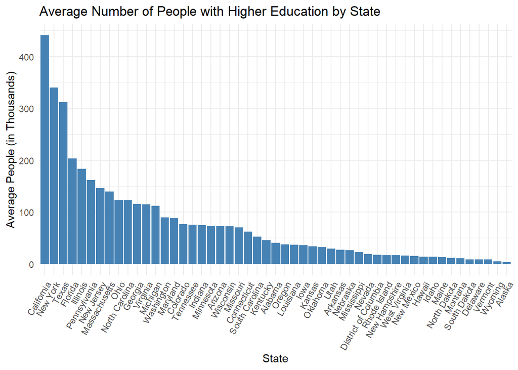

```r
#Plot figure

ggplot(average_education, aes(x = reorder(GeoName, -avg_education), y = avg_education/1e3)) +
  geom_bar(stat = "identity", fill = "steelblue") +
  theme_minimal() +
  labs(
    title = "Average Number of People with Higher Education by State",
    x = "State",
    y = "Average People (in Thousands)"
  ) +
  theme(axis.text.x = element_text(angle = 60, hjust = 1))
```

We created a new variable, average income and average education per state, to gain a better understanding of income and education trends across the United States during the period analysed. Creating an average per state helps to smooth out year-to-year fluctuations and provides a more representative measure of income and education levels.

## 3.3 Visualize temporal variation

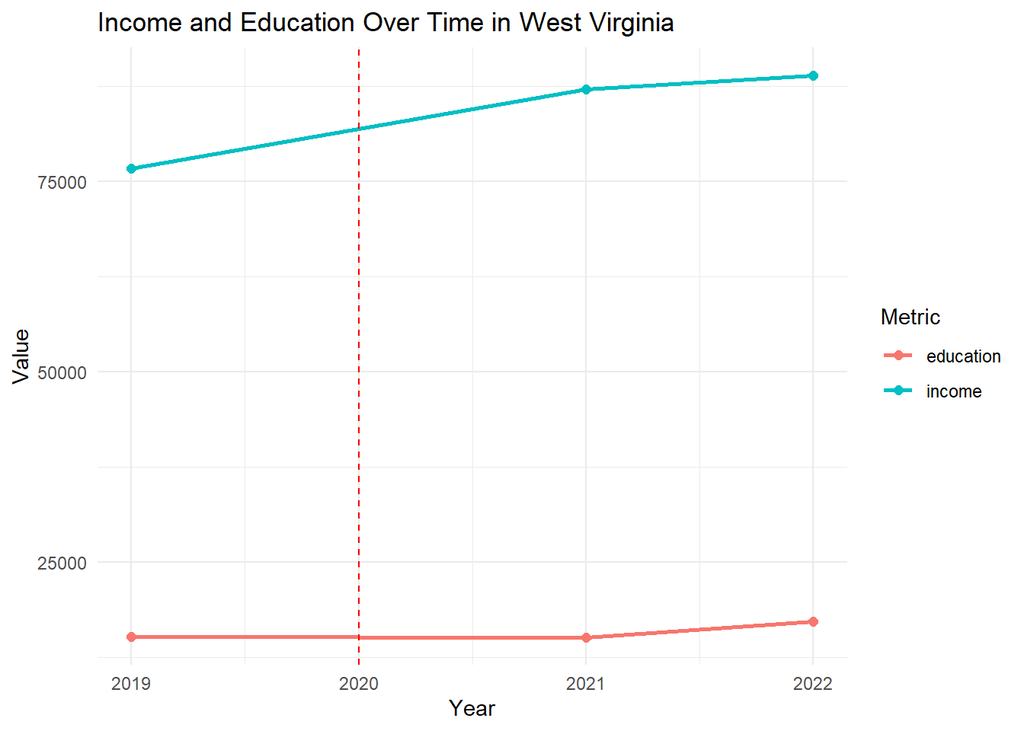

```r
# Plot
ggplot(plot_temporal, aes(x = year, y = value, color = Metric)) +
  geom_line(size = 1) +
  geom_point(size = 2) +
  geom_vline(xintercept = 2020, linetype = "dashed", color = "red") +
  labs(
    title = "Income and Education Over Time in West Virginia",
    x = "Year",
    y = "Value",
    color = "Metric"
  ) +
  theme_minimal()
```

In this plot we try to show the relationship and the linkage between education, and income throughout 2019 to 2022. We selected West Virginia because it is the state with the highest obesity rate. The plot also tries to show if covid(2020) had a causal relationship with the increase in education and income. We did not use the 2020 data since during the covid there was no data collected from our source.

## 3.4 Visualize spatial variation

[figure not shown]

```r
# Plot average education per state with color scale in millions

ggplot(education_map, aes(x = long, y = lat, group = group, fill = avg_education)) +
  geom_polygon(color = "white") +
  coord_fixed(1.3) +
  labs(
    title = "Average Number of People with Higher Education by State",
    fill = "Average Education (Millions)"
  ) +
  scale_fill_viridis_c(option = "plasma", direction = -1, labels = scales::label_number(suffix = "M", accuracy = 1)) +
  theme_void()
```

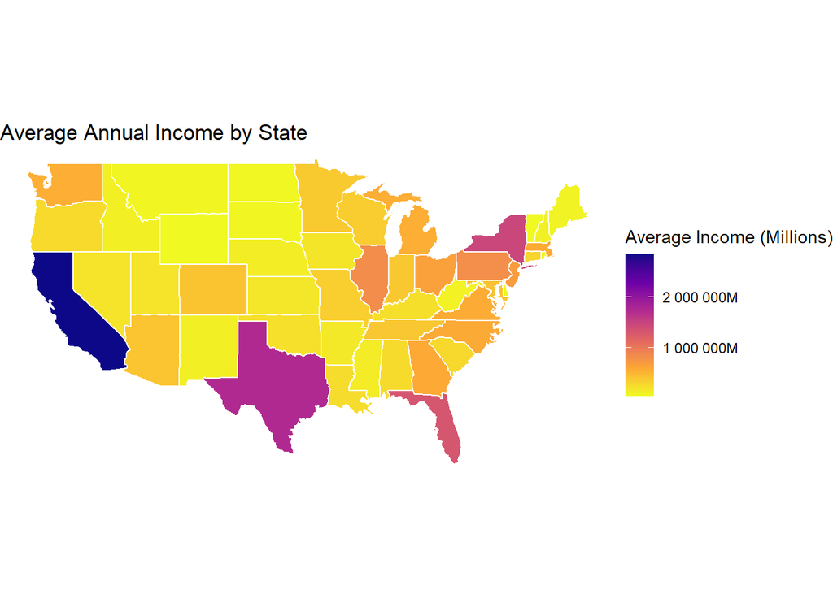

```r
# Plot average income per state with color scale in millions

ggplot(income_map, aes(x = long, y = lat, group = group, fill = avg_income)) +
  geom_polygon(color = "white") +
  coord_fixed(1.3) +
  labs(
    title = "Average Annual Income by State",
    fill = "Average Income (Millions)"
  ) +
  scale_fill_viridis_c(option = "plasma", direction = -1, labels = scales::label_number(suffix = "M", accuracy = 1)) +
  theme_void()
```

In the spatial variation we graphs, we used the map of the United States of America. There are two graphs(One showing the average education levels, the other one showing the average income levels). Darker the shade of the color of the state, higher the variable becomes. The plots above are relevant to obesity because it helps us visualize which states show low results in the indicators we chose(income and education) for obesity.

## 3.5 Visualize sub-population variation

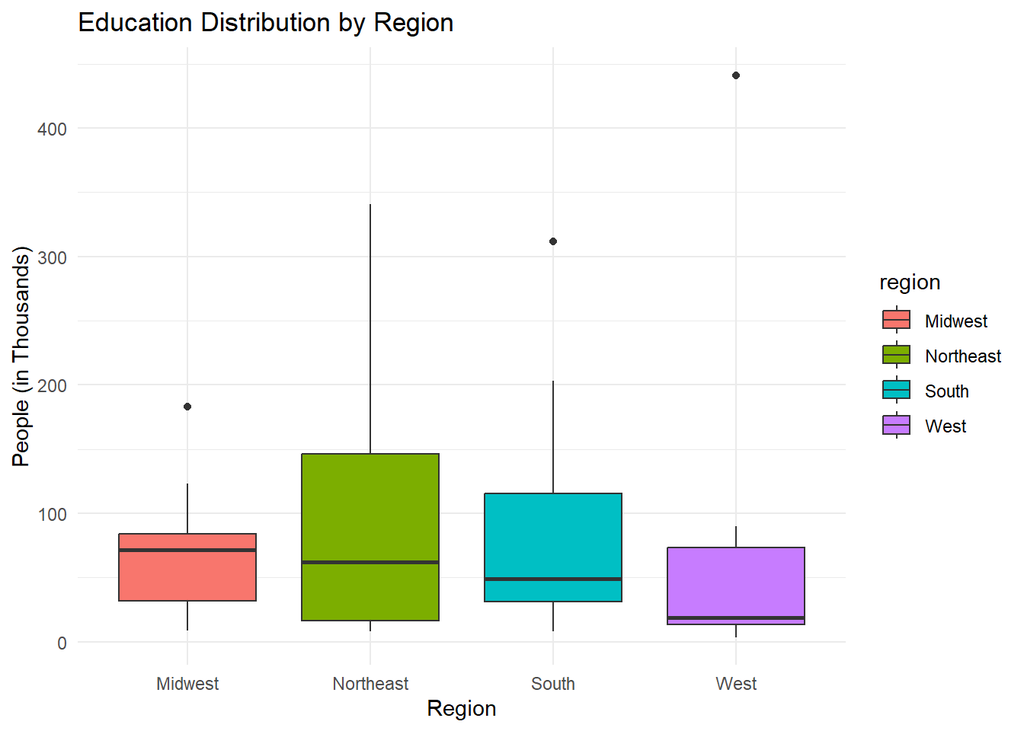

```r
#Plot
ggplot(education_states, aes(x = region, y = avg_education / 1e3, fill = region)) +
  geom_boxplot() +
  theme_minimal() +
  labs(
    title = "Education Distribution by Region",
    x = "Region",
    y = "People (in Thousands)"
  )
```

This plot visualizes the distribution of the number of people by region who had attained a bachelor’s degree or higher. It is relevant to our research because education is one of the most important variables we are investigating in relation to obesity across the United States. By comparing regions such as the Midwest, Northeast, South, and West, we can observe how education levels changed geographically.

## 3.6 Event analysis

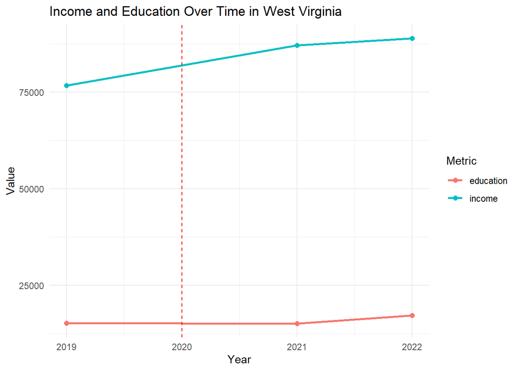

```r
# Plot
ggplot(plot_temporal, aes(x = year, y = value, color = Metric)) +
  geom_line(size = 1) +
  geom_point(size = 2) +
  geom_vline(xintercept = 2020, linetype = "dashed", color = "red") +
  labs(
    title = "Income and Education Over Time in West Virginia",
    x = "Year",
    y = "Value",
    color = "Metric"
  ) +
  theme_minimal()
```

# Part 4 - Discussion

# Part 5 - Reproducibility

## 5.1 Github repository link

https://github.com/matildemaio/Obesity

## 5.2 Reference list

Barraclough, A. (2025, January 29). Healthy eating now twice as expensive as junk food, study finds. Women’s Health. https://www.womenshealthmag.com/uk/food/healthy-eating/a63598807/healthy-eating-twice-as-expensive-as-junk-food-study/

BEA. (2025, March 28). BEA Interactive Data Application. Apps.bea.gov. https://apps.bea.gov/itable/?ReqID=70&step=1&_gl=1 CDC. (2025, January 16). Adult Obesity Facts. Obesity. https://www.cdc.gov/obesity/adult-obesity-facts/index.html#print States, U. (2025). Explore Census Data. Census.gov. https://data.census.gov/table/ACSST5Y2022.S1501?q=education+by+state&t=Populations+and+People World Obesity. (2024). Ranking (% Obesity by country). World Obesity Federation Global Obesity Observatory. https://data.worldobesity.org/rankings/

Side Note: -BEA does not conduct original surveys; they compile data from federal agencies, administrative reports, and NIPA reports from the government. -Data.census.gov comes from the U.S. Census Bureau’s American Community Survey (ACS)